# November 2020 Georgia Senate Special

Kristle Chester

11/21/2020

## Birth State (Historic)

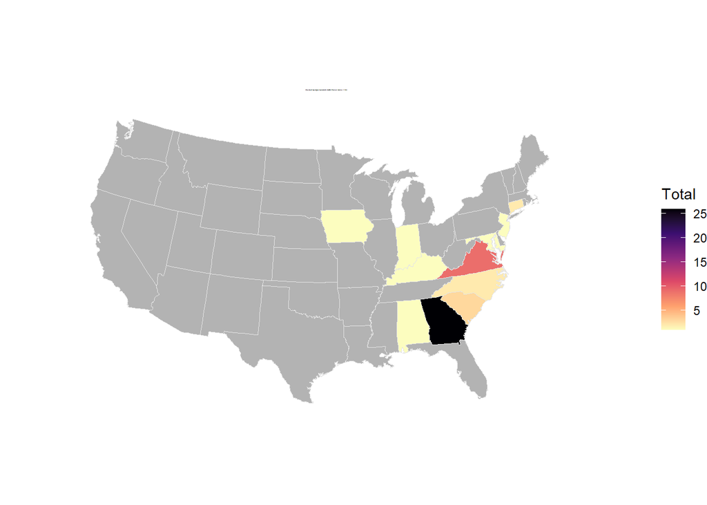

## Post Civil War

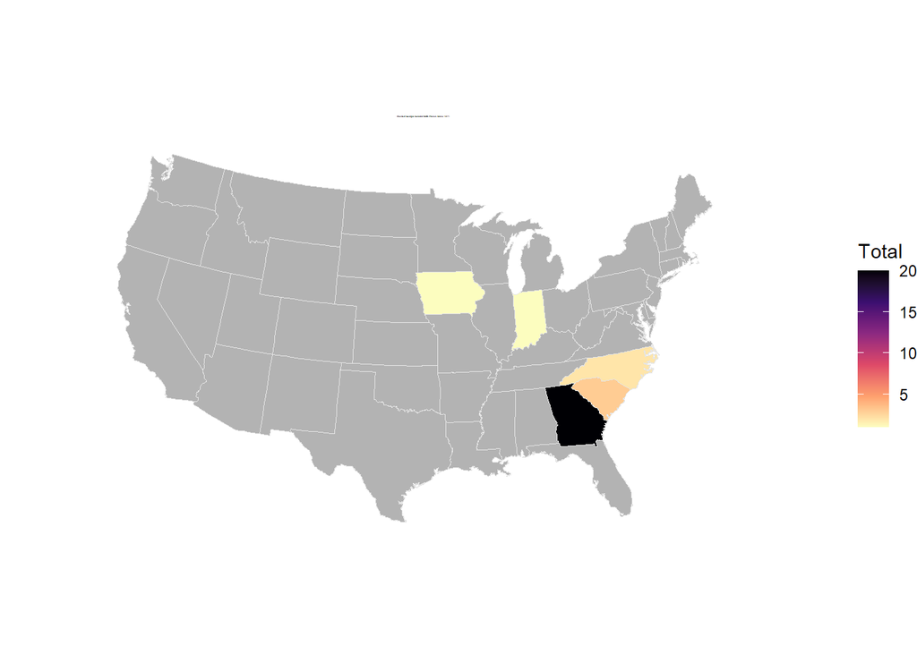

## Senator Birth Map Sequence

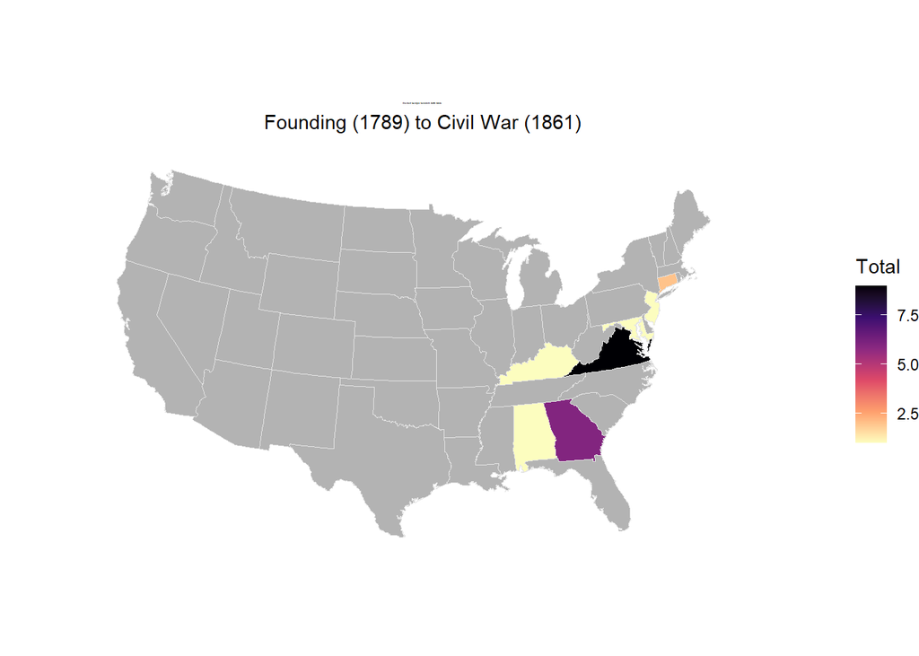

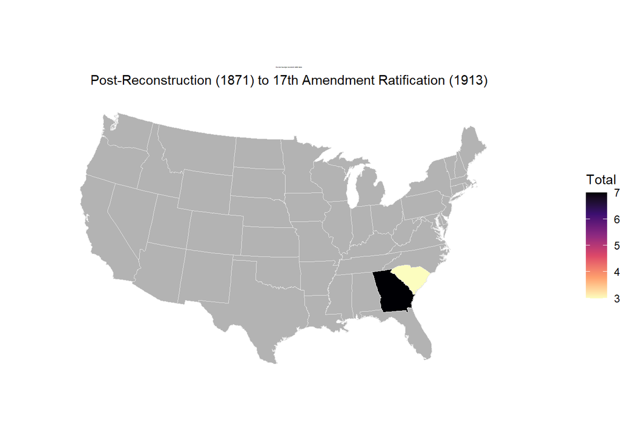

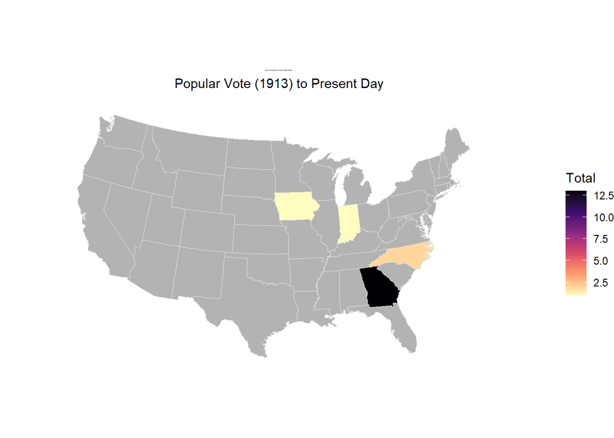

## Animated Birthplace Map

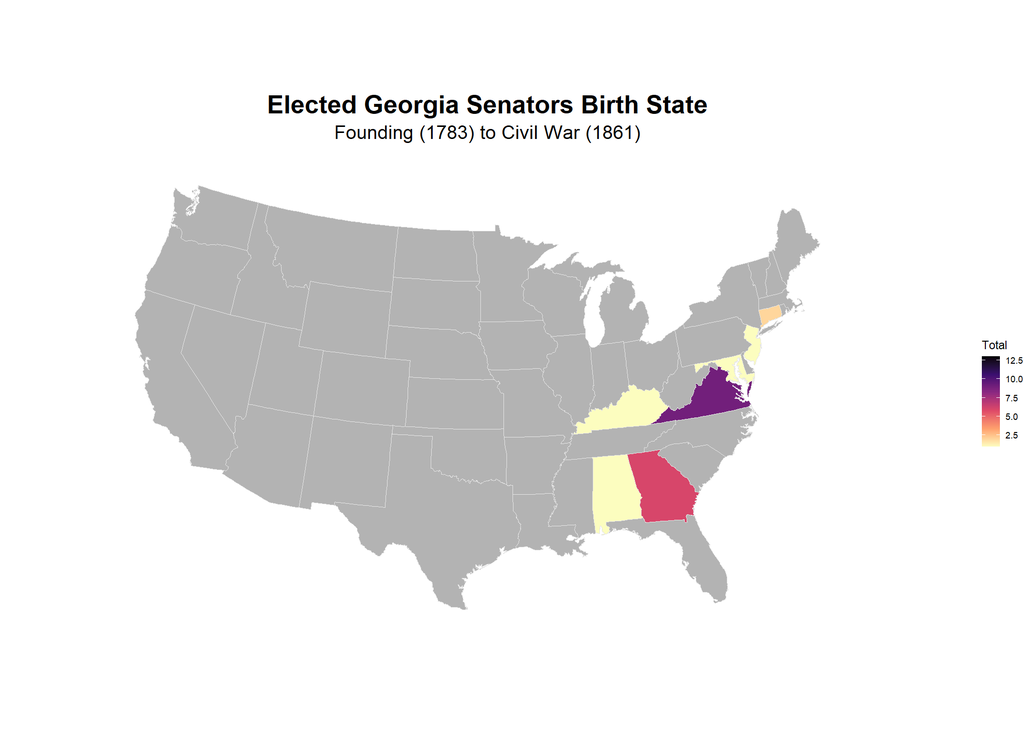

|  | Total | Democratic | Republican | Independent | Libertarian |
| --- | --- | --- | --- | --- | --- |
| 160 | 4914361 | 2378312 | 2426120 | 59205 | 35431 |

|  | Democratic | Republican | Independent | Libertarian |
| --- | --- | --- | --- | --- |
| 160 | 48.40% | 49.37% | 1.20% | 0.72% |

|  | County | Total | Democratic | Republican | Independent | Libertarian |
| --- | --- | --- | --- | --- | --- | --- |
| 1 | Cherokee | 142240 | 40266 | 98081 | 1699 | 1713 |
| 2 | Clayton | 111262 | 94439 | 14224 | 2015 | 327 |
| 3 | Cobb | 388963 | 211845 | 166815 | 5032 | 3692 |
| 4 | De Kalb | 367133 | 300151 | 59575 | 4034 | 2090 |
| 5 | Douglas | 68441 | 42372 | 24760 | 759 | 375 |
| 6 | Fayette | 70942 | 31610 | 37720 | 814 | 567 |
| 7 | Fulton | 517607 | 364153 | 141649 | 6437 | 3423 |
| 8 | Gwinnett | 402715 | 230580 | 161992 | 5409 | 3197 |
| 9 | Henry | 121470 | 72300 | 46783 | 1408 | 687 |
| 10 | Rockdale | 44212 | 30865 | 12569 | 461 | 208 |

[output cut: 1 more lines]

|  | County | Democratic | Republican | Independent | Libertarian |
| --- | --- | --- | --- | --- | --- |
| 1 | Cherokee | 28.31% | 68.95% | 1.19% | 1.20% |
| 2 | Clayton | 84.88% | 12.78% | 1.81% | 0.29% |
| 3 | Cobb | 54.46% | 42.89% | 1.29% | 0.95% |
| 4 | De Kalb | 81.76% | 16.23% | 1.10% | 0.57% |
| 5 | Douglas | 61.91% | 36.18% | 1.11% | 0.55% |
| 6 | Fayette | 44.56% | 53.17% | 1.15% | 0.80% |
| 7 | Fulton | 70.35% | 27.37% | 1.24% | 0.66% |
| 8 | Gwinnett | 57.26% | 40.22% | 1.34% | 0.79% |
| 9 | Henry | 59.52% | 38.51% | 1.16% | 0.57% |
| 10 | Rockdale | 69.81% | 28.43% | 1.04% | 0.47% |

Extra Calculations:

- Percent Presidential Voters who Also Voted in the Senate Race (Perdue): 0.9907358
- Percent Presidential Voters who Also Voted in the Special Senate Race: 0.9831707
- Percent Senate Race Voters who Also Voted in the Special: 0.9923642

Small Counties:

- % Total Statewide Vote in Counties with less than 5000 votes: 0.028926
- % Total Statewide Vote in Counties with less than 10000 votes: 0.0770965
- % Total Statewdie Vote in Counties with less than 15000 votes: 0.1422785

Republican

- % Total Statewide Republican Votes Counties with less than 5000 votes: 0.0359512
- % Total Statewide Republican Votes Counties with less than 10000 votes: 0.1054136
- % Total Statewide Republican Votes Counties with less than 15000 votes: 0.1985124

Democrat

- % Total Statewide Democratic Votes Counties with less than 5000 votes: 0.0220652
- % Total Statewide Democratic Votes Counties with less than 10000 votes: 0.0489006
- % Total Statewide Democratic Votes Counties with less than 15000 votes: 0.0862498

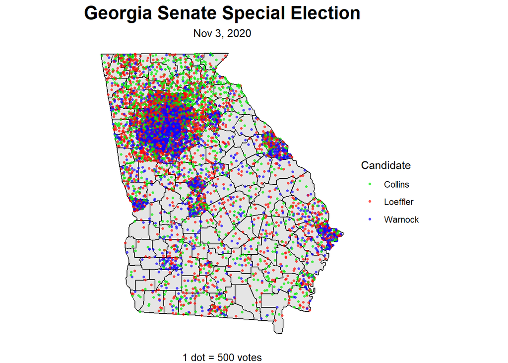

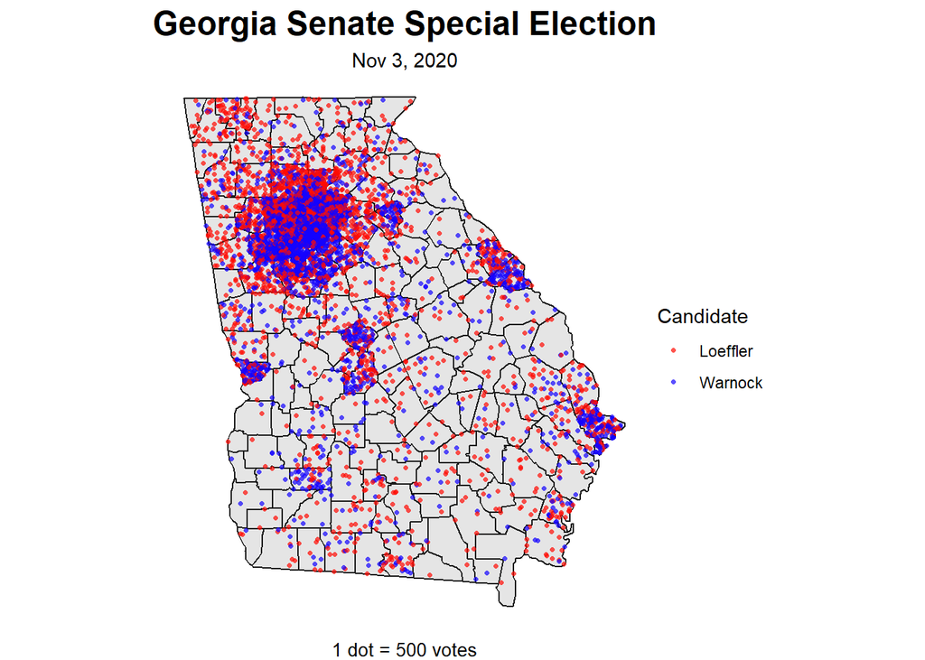

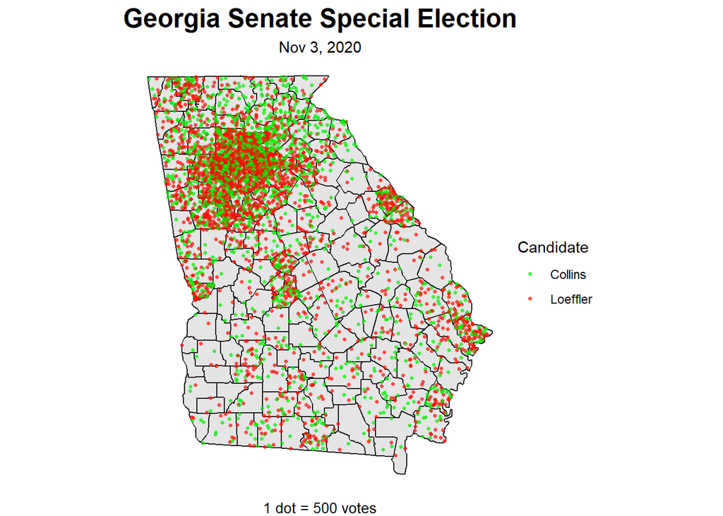

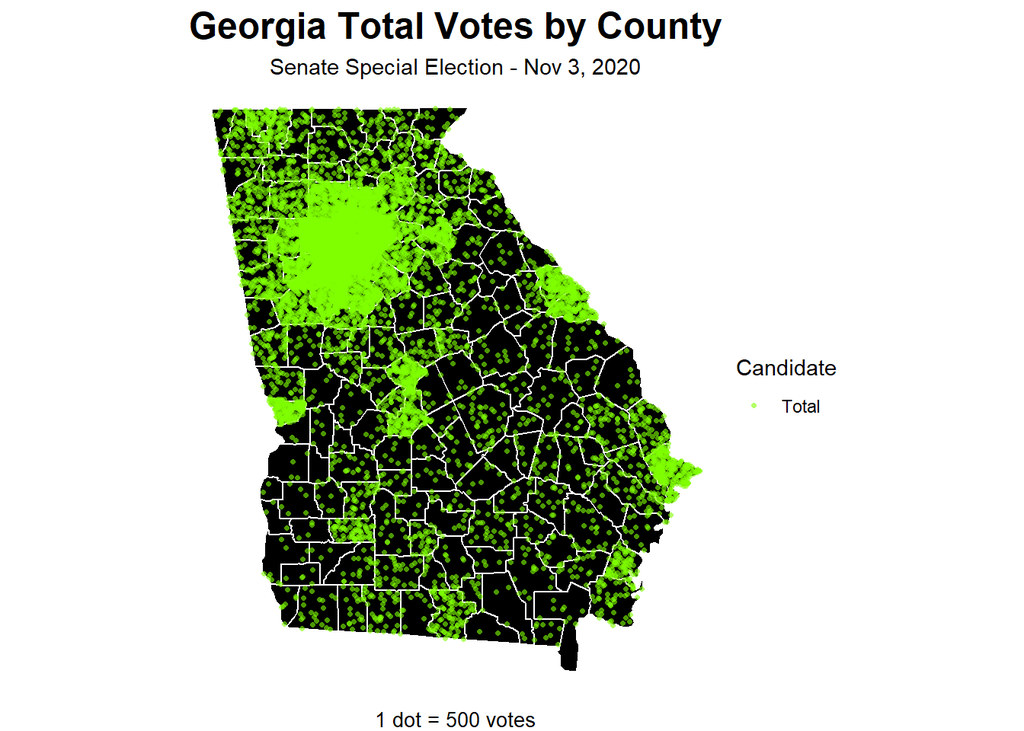

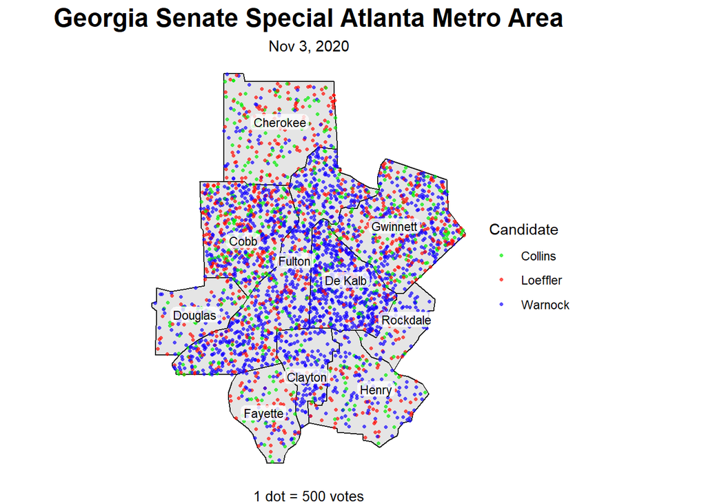

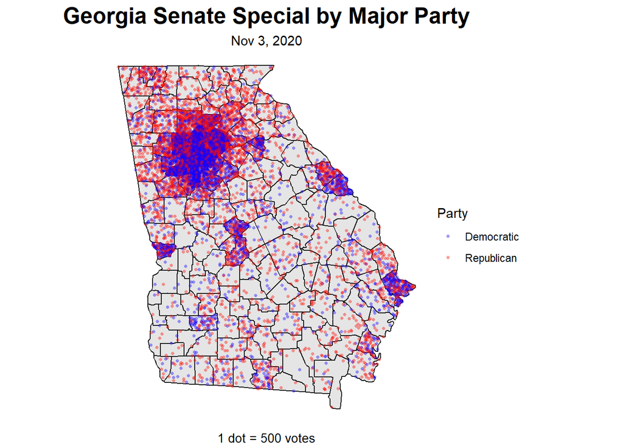

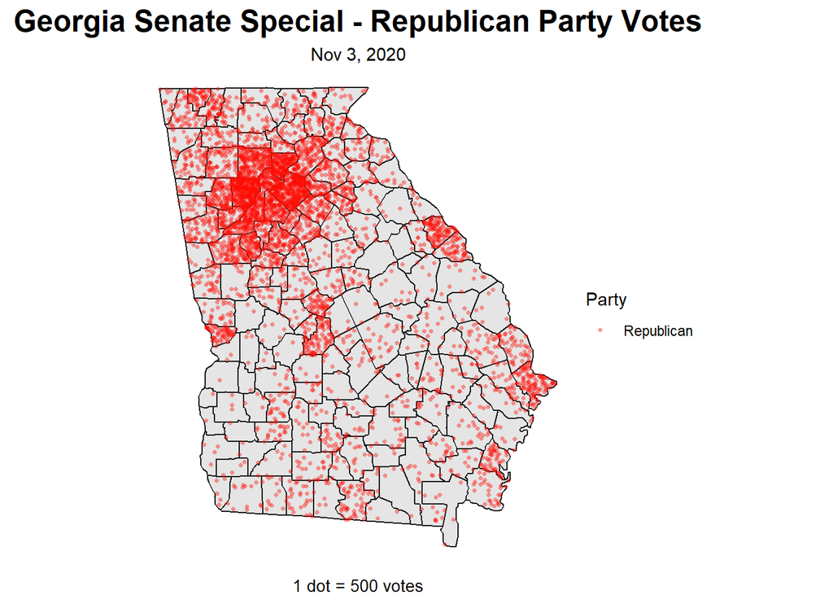

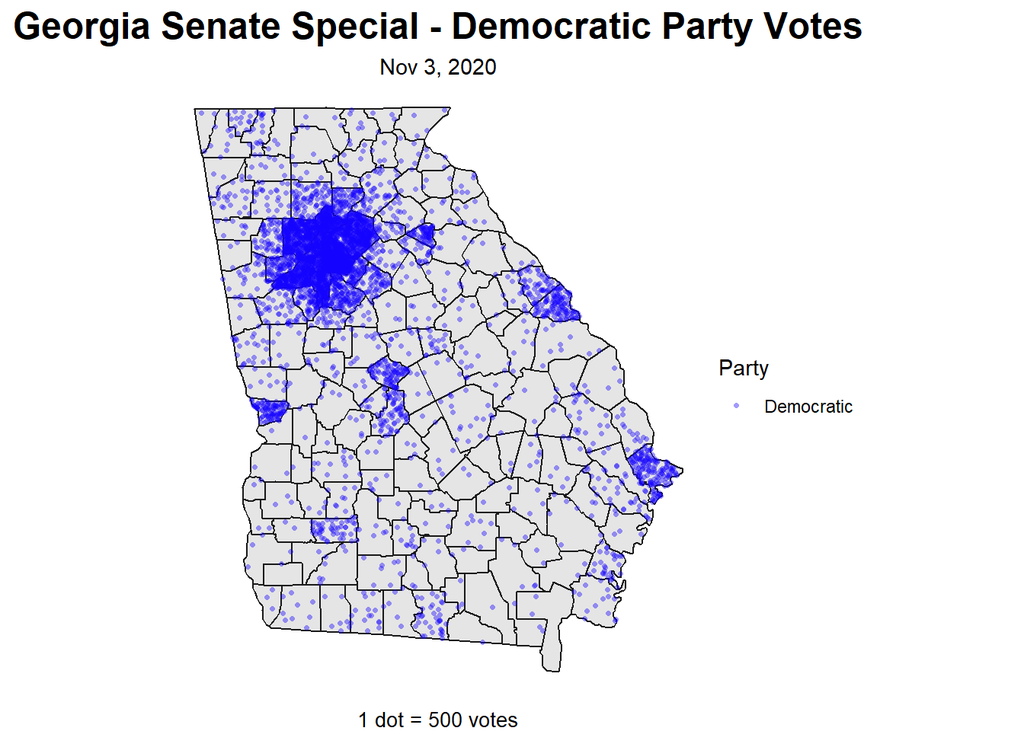

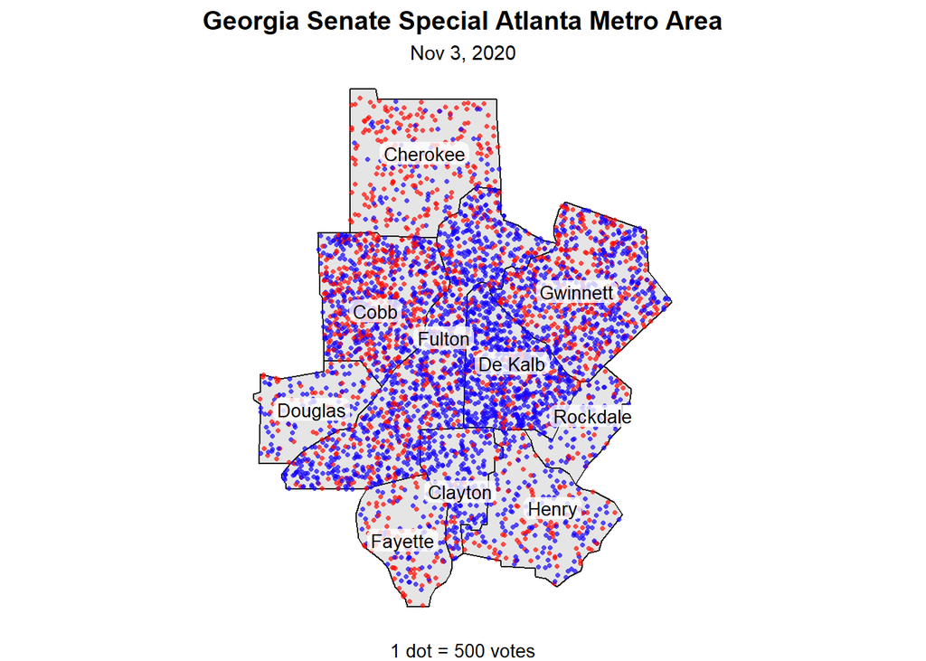